# Task

self

2025-04-20

Qno1

```r
library(readxl)

data <- read_excel("C:/Users/hp/Downloads/clusting/ktc_2023005913.xlsx")

str(data)
```

```
## tibble [600 × 7] (S3: tbl_df/tbl/data.frame)
##  $ Customer : num [1:600] 1 2 3 4 5 6 7 8 9 10 ...
##  $ Age      : num [1:600] 64 68 31 53 67 52 54 56 31 76 ...
##  $ Income   : num [1:600] 121536 95245 84154 111463 76295 ...
##  $ Marital  : chr [1:600] "single" "married" "married" "married" ...
##  $ Children : num [1:600] 0 1 0 2 0 1 0 0 0 0 ...
##  $ Education: chr [1:600] "high_school" "bachelors" "bachelors" "bachelors" ...
##  $ Home     : chr [1:600] "own" "own" "own" "own" ...
```

```r
library(dplyr)
data_binary <- data %>%
  mutate(
    Retirement    = ifelse(Age > 62, 1, 0),
    MiddleUpper   = ifelse(Income > 85000, 1, 0),
    Married       = ifelse(Marital == "married", 1, 0),
    FamilyPlan    = ifelse(Children > 0, 1, 0),
    MastersPlus   = ifelse(Education %in% c("masters", "more than masters"), 1, 0),
    Own           = ifelse(Home == "own", 1, 0)
  )

data_cluster <- data_binary %>%
  select(Retirement, MiddleUpper, Married, FamilyPlan, MastersPlus, Own)

head(data_cluster)
```

```
## # A tibble: 6 × 6
##   Retirement MiddleUpper Married FamilyPlan MastersPlus   Own
##        <dbl>       <dbl>   <dbl>      <dbl>       <dbl> <dbl>
## 1          1           1       0          0           0     1
## 2          1           1       1          1           0     1
## 3          0           0       1          0           0     1
## 4          0           1       1          1           0     1
## 5          1           0       0          0           0     1
## 6          0           0       1          1           1     1
```

Qno2

```r
library(cluster)

dist_matrix <- daisy(data_cluster, metric = "gower")
```

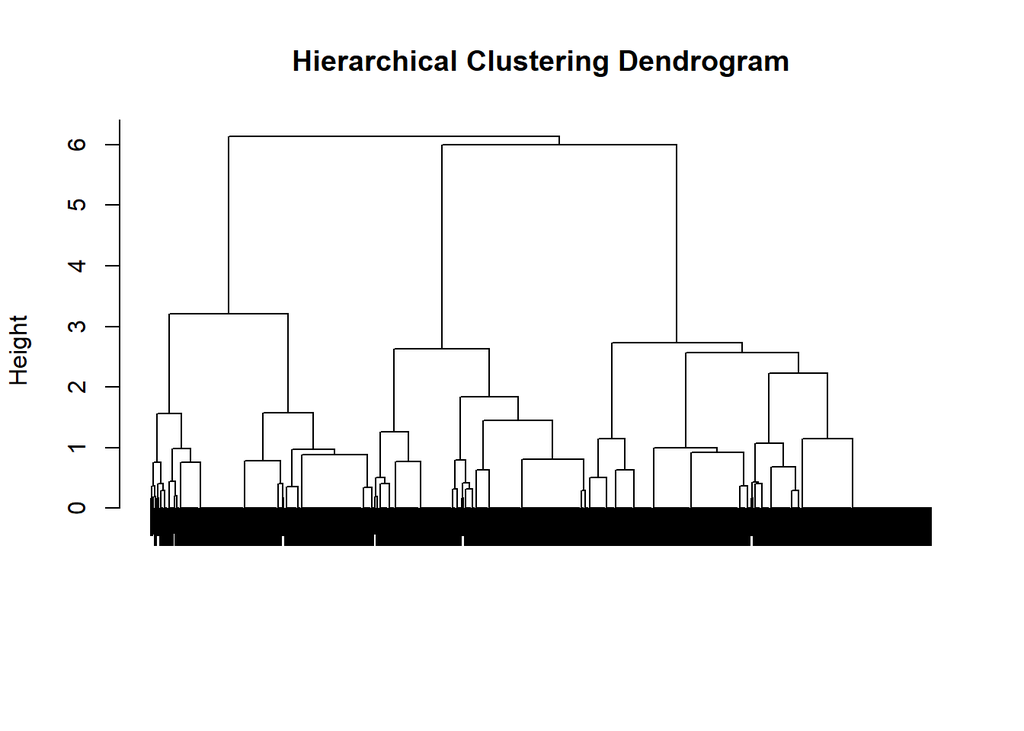

```r
#Perform hierarchical clustering using Ward’s method
hc <- hclust(dist_matrix, method = "ward.D2")

#dendrogram
plot(hc, labels = FALSE, main = "Hierarchical Clustering Dendrogram", xlab = "", sub = "")
```

```r
# Choose optimal number of clusterS

clusters <- cutree(hc, k = 4)

# Add cluster assignments to data
data_clustered <- data_binary %>%
  mutate(Cluster = as.factor(clusters))

library(dplyr)

cluster_summary <- data_clustered %>%
  group_by(Cluster) %>%
  summarise(
    Count = n(),
    Retirement = mean(Retirement),
    MiddleUpper = mean(MiddleUpper),
    Married = mean(Married),
    FamilyPlan = mean(FamilyPlan),
    MastersPlus = mean(MastersPlus),
    Own = mean(Own)
  )

print(cluster_summary)
```

```
## # A tibble: 4 × 8
##   Cluster Count Retirement MiddleUpper Married FamilyPlan MastersPlus   Own
##   <fct>   <int>      <dbl>       <dbl>   <dbl>      <dbl>       <dbl> <dbl>
## 1 1         101     1            0.347 0.00990      0.149      0.158  0.980
## 2 2          71     1            0.366 0.930        0.803      0.0141 0.817
## 3 3         164     0.0549       0.549 0.988        0.884      0.220  0.640
## 4 4         264     0            0.530 0.0379       0.201      0.144  0.583
```

qno3

```r
library(dplyr)
library(factoextra)
```

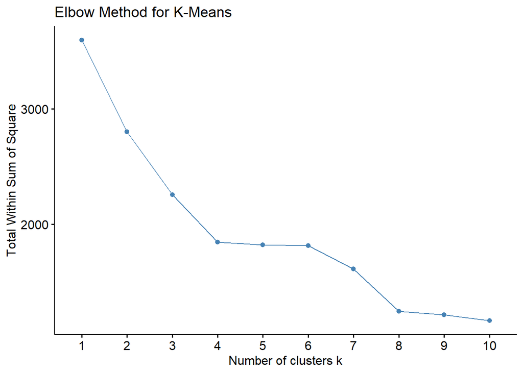

```r
# variables for clustering
data_kmeans <- data_binary %>%
  select(Age, Income, Married, Children, MastersPlus, Own)

data_scaled <- scale(data_kmeans)

# Determine optimal number of clusters using the Elbow method
fviz_nbclust(data_scaled, kmeans, method = "wss") +
  labs(title = "Elbow Method for K-Means")
```

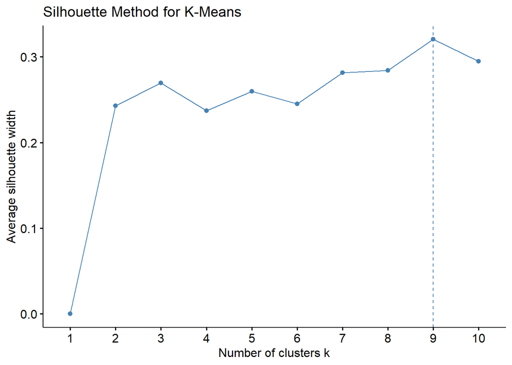

```r
# Silhouette method too
fviz_nbclust(data_scaled, kmeans, method = "silhouette") +
  labs(title = "Silhouette Method for K-Means")
```

```r
set.seed(123)
kmeans_result <- kmeans(data_scaled, centers = 4, nstart = 25)

# Add cluster labels to the dataset
data_kmeans_clustered <- data_kmeans %>%
  mutate(Cluster = as.factor(kmeans_result$cluster))

# Characterize clusters
cluster_summary_kmeans <- data_kmeans_clustered %>%
  group_by(Cluster) %>%
  summarise(
    Count = n(),
    Age = round(mean(Age), 1),
    Income = round(mean(Income), 1),
    Married = round(mean(Married), 2),
    Children = round(mean(Children), 2),
    MastersPlus = round(mean(MastersPlus), 2),
    Own = round(mean(Own), 2)
  )

print(cluster_summary_kmeans)
```

```
## # A tibble: 4 × 8
##   Cluster Count   Age Income Married Children MastersPlus   Own
##   <fct>   <int> <dbl>  <dbl>   <dbl>    <dbl>       <dbl> <dbl>
## 1 1          90  48.3 90007     0.39     0.64        1     0.66
## 2 2         154  57.3 84700.    0.98     1.66        0.01  0.94
## 3 3         143  36.6 77899     0.37     0.71        0     0
## 4 4         213  55.9 86636.    0        0.27        0     1
```

Qno4 ##Comparison: Hierarchical Clustering vs K-Means Clustering

Based on the analysis, the k-means clustering approach from Part 3 is recommended for GCC’s client. While hierarchical clustering using binary variables provided interpretable customer profiles based on logical conditions (such as being retired, married, or owning a home), the k-means clustering approach leveraged richer numerical variables like age and income in combination with key binary indicators. This resulted in more balanced and nuanced clusters that better reflect real-world customer segmentation. The four k-means clusters identified distinct groups: younger renters with lower income and education levels; mid-aged, higher-income professionals with advanced degrees; married individuals with families and moderate income; and older homeowners with low family involvement. These segments are highly actionable for targeted marketing strategies, offering the client meaningful insights into how to tailor messaging, products, and services to each group. Therefore, the customer profiles derived from the k-means clustering are more comprehensive and practical for the client’s segmentation goals.